# #neinzum12htag

[figure not shown]

[figure not shown]

[figure not shown]

[figure not shown]

[figure not shown]

[figure not shown]

[figure not shown]

[figure not shown]

### Vollzeitbeschäftigte haben in Österreich bereits sehr lange Arbeitszeiten

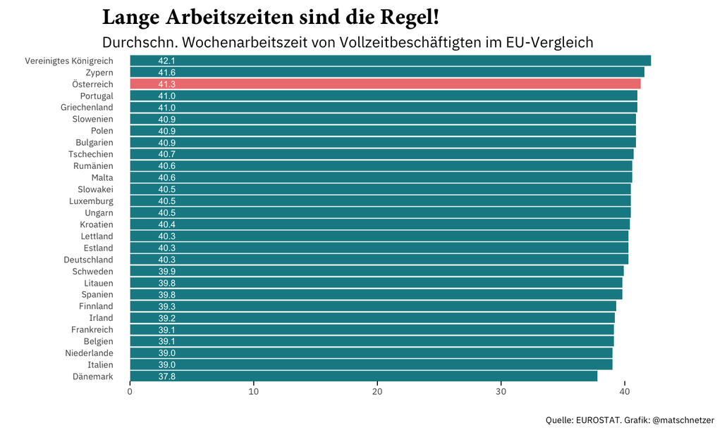

- Die Grafik zeigt die durchschnittliche, wöchentliche Normalsarbeitszeit von Vollzeitbeschäftigten im Jahr 2017
- Österreich ist im EU-Vergleich nach Großbritannien und Zypern an der Spitze der langen Arbeitszeiten
- Quelle: Arbeitskräfteerhebung, Eurostat

### Österreich ist trotz jüngstem Trend zu kürzerer Vollzeitarbeit noch deutlich über dem EU-15-Schnitt

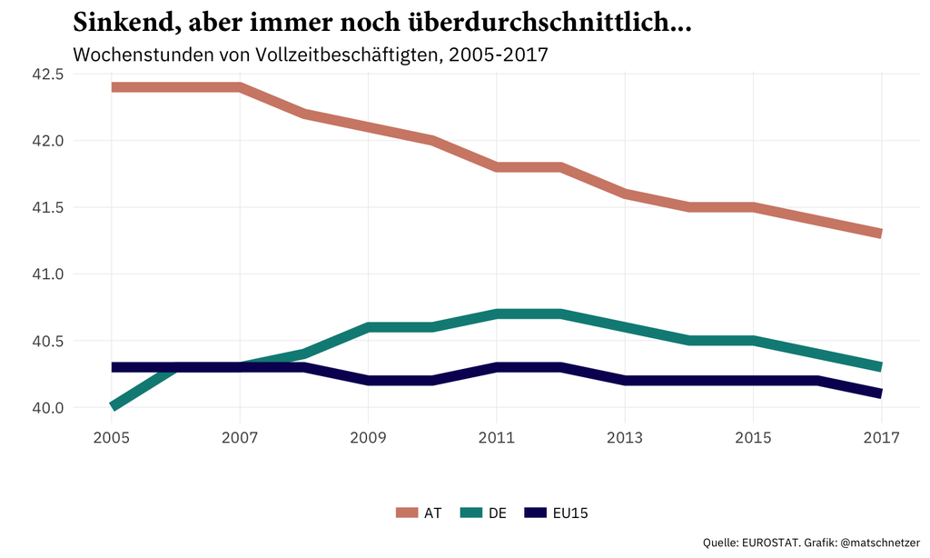

- Die Grafik zeigt die zeitliche Entwicklung der Wochenstunden von Vollzeitbeschäftigten von 2005-2017
- Österreichs verzeichnete in den letzten Jahren eine positive Entwicklung, wonach die durchschnittliche Wochenarbeitszeit rückläufig war (u.U. auch durch die schwache Konjunktur).
- Dennoch arbeiten Menschen in Österreich deutlich länger als im EU-15-Schnitt und auch in Deutschland.
- Quelle: Arbeitskräfteerhebung, Eurostat

### 2017 wurden 250 Mio. Überstunden geleistet. Von wem?

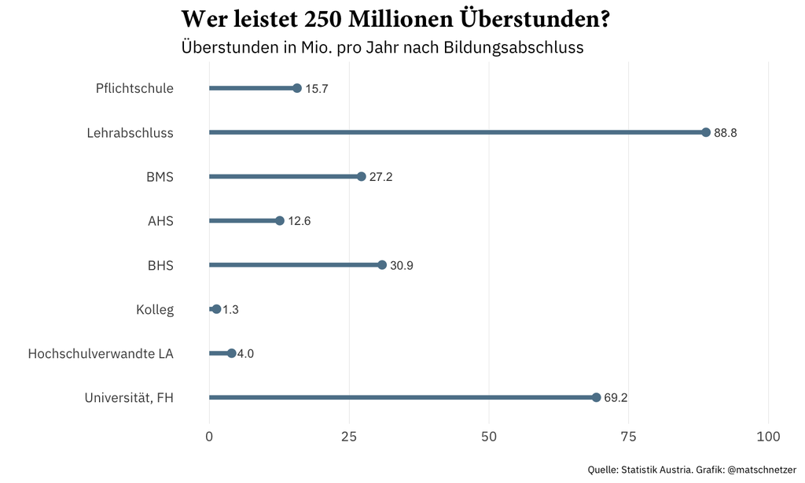

### Jede 5. in Österreich geleistete Überstunde ist unvergütet

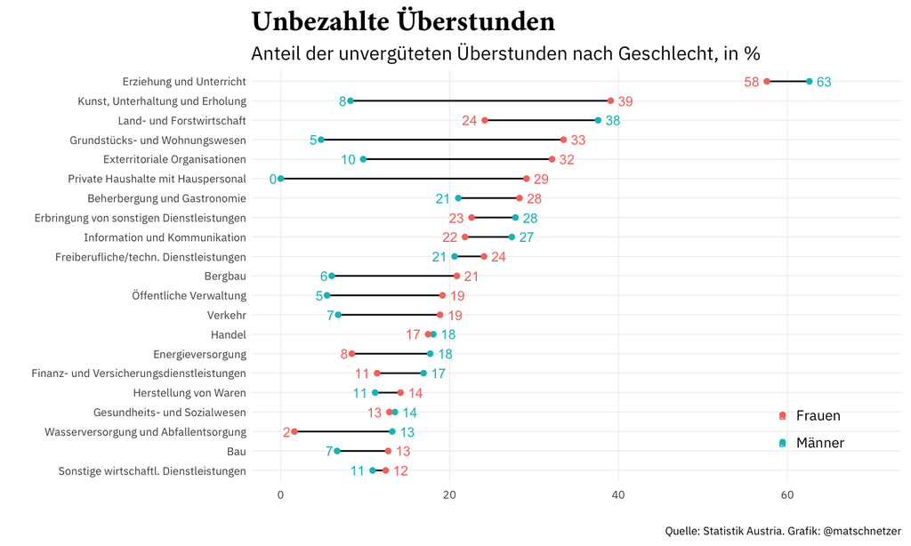

- Die Grafik zeigt den Anteil von unvergüteten an den gesamt geleisteten Mehr- und Überstunden in Österreich nach Branche und Geschlecht für 2017
- Nicht vergütet bedeutet, dass die Überstunde weder in Zeit noch in Geld abgegolten ist
- Im Durchschnitt ist etwa jede 5. Überstunde in Österreich unvergütet
- Quelle: Arbeitskräfteerhebung, Statistik Austria

### Viele Menschen werden außerhalb der Arbeitszeit bezüglich ihrer Arbeit kontaktiert

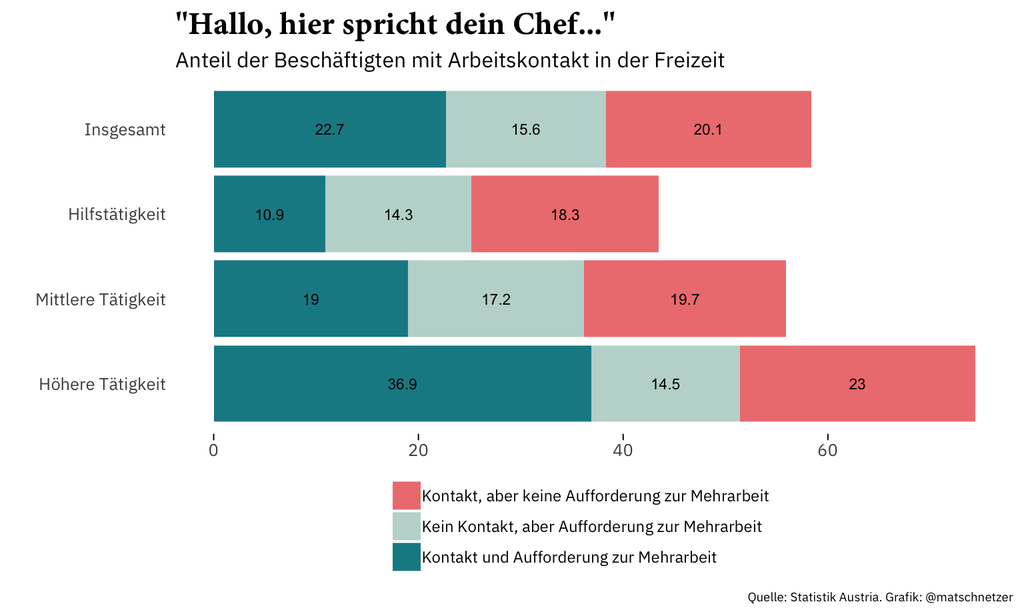

- Die Grafik zeigt den Anteil der unselbständig Beschäftigten, die innerhalb der letzten 2 Monate außerhalb der Arbeitszeit bezüglich ihrer Arbeit kontaktiert wurden.
- Mehr als die Hälfte der Beschäftigten wurden in irgendeiner Form kontaktiert und/oder zur Mehrarbeit aufgefordert. Der Anteil der Kontaktaufnahme steigt mit der ausgeübten Tätigkeit.
- Quelle: Statistik Austria (2016): Arbeitsorganisation und Arbeitszeitgestaltung, Modul der Arbeitskräfteerhebung 2015, S. 45

### Viele Menschen sind mit ihrer Arbeitszeit bislang zufrieden, zahlreiche möchten aber verkürzen

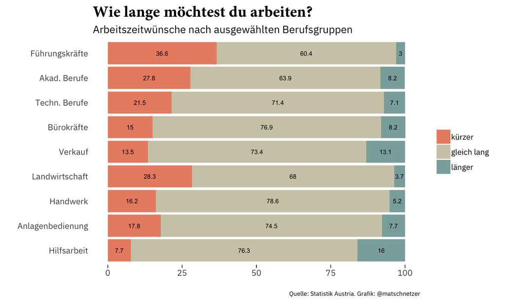

- Die Grafik zeigt die Arbeitszeitwünsche nach ausgewählten Berufsgruppen in Prozent.
- Während die meisten Beschäftigten mit ihrer Arbeitszeit zufrieden sind, würden viele Menschen gerne ihre Arbeitszeit verkürzen. Nur wenige würden gerne mehr arbeiten, vor allem in Branchen mit hohem Teilzeitanteil.
- Quelle: Statistik Austria (2016): Arbeitsorganisation und Arbeitszeitgestaltung, Modul der Arbeitskräfteerhebung 2015, S. 37

### Vollzeitbeschäftigte wünschen sich eine Arbeitszeitverkürzung, Teilzeitbeschäftigte würden gerne mehr arbeiten

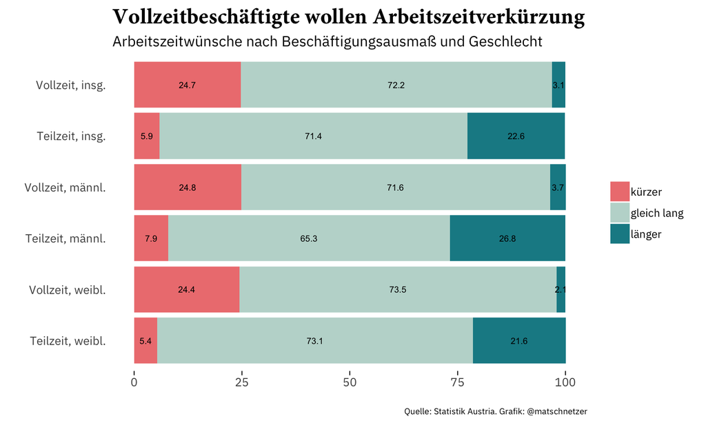

- Die Grafik zeigt die Arbeitszeitwünsche nach Beschäftigungsausmaß (Vollzeit/Teilzeit) und nach Geschlecht
- Ein Viertel der Vollzeiterwerbstätigen wünscht sich, weniger zu arbeiten, wohingegen mehr als jede(r) fünfte Teilzeiterwerbstätige gerne mehr arbeiten würde. Arbeiten Männer in Teilzeit, so wollen sie um etwa fünf Prozentpunkte häufiger ihre Arbeitsstunden aufstocken als Frauen.
- Quelle: Statistik Austria (2016): Arbeitsorganisation und Arbeitszeitgestaltung, Modul der Arbeitskräfteerhebung 2015, S. 107ff

### Vor allem Frauen können aufgrund von Betreuungspflichten ihre Arbeitszeit nicht ausweiten

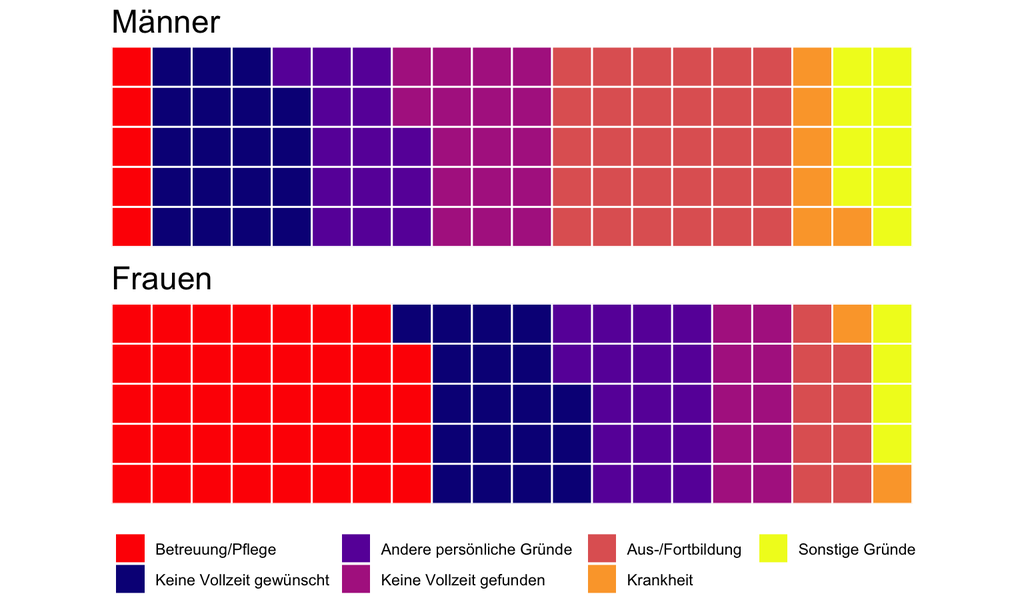

- Die Grafik zeigt die Gründe von Männern und Frauen für Teilzeitarbeit.
- Der hauptsächliche Grund für Teilzeitarbeit von Frauen sind Betreuungs- und Pflegeverpflichtungen, während bei Männern Aus- und Fortbildung der stärkste Grund für Teilzeit ist.
- Vor allem für Frauen ist eine Ausweitung der Arbeitszeit praktisch nicht mit weiteren Verpflichtungen vereinbar, da unbezahlte Arbeit zum überwiegenden Teil von Frauen geleistet wird. Eine gleiche Aufteilung der Verpflichtungen zwischen den Geschlechtern ist eine Grundvoraussetzung für eine erhöhte Erwerbsbeteiligung von Frauen.
- Quelle: Mikrozensus 2014, Statistik Austria